# Mixed Cumulative Probit Algorithm Vignette

## Visualizations

The following code provides examples of the different types of visualizations that can be produced using the results generated from models optimized using the MCP algorithm.

### Ordinal Posterior Distributions by Stage

Similar to the concept of `generate_ci_ord()`, these two visualizations are meant to display the outputs returned by univariate ordinal models.

#### Point and “Errorbars”

Using the output from `generate_ci_ord()`, we can visualize the point estimate and credible interval for each stage of an univariate ordinal variable.

```
For this demonstration, we use the data frame of max_M1 generated using `generate_ci_ord()`.
```

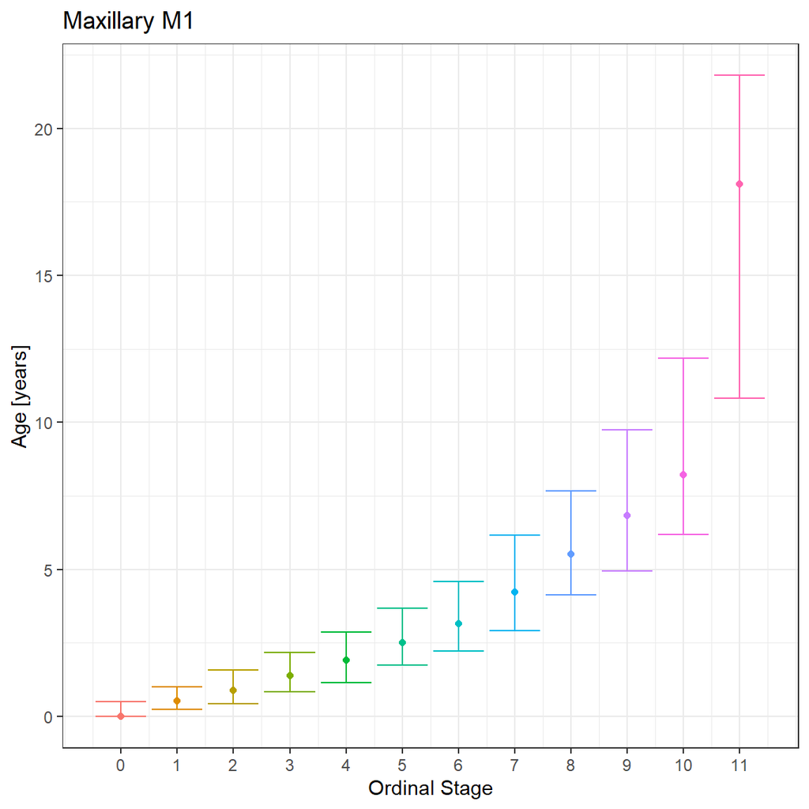

```r
ggplot(max_M1_df) +
  geom_errorbar(aes(x=ord_stage, ymin=lower95,   # factor stages
                    ymax=upper95, color=factor(ord_stage))) +  # color by stage
  geom_point(aes(x=ord_stage, y=point_est,
                 color=factor(ord_stage))) +  # point estimate by stage
  scale_x_continuous(breaks=c(0:11)) +  # add ticks on x-axis at each stage
  labs(x="Ordinal Stage", y="Age [years]", title="Maxillary M1") +  # labels
  theme_bw() +  # black and white plot space
  theme(legend.position="none")  # remove legend
```

**NOTE:** The ordinal stages used by any model generated using the MCP pipeline automatically start at 0 and are re-coded as integers. These may not reflect your original scores, and therefore adjustments can be made such as using `scale_x_continuous(labels=c("vector","of","stages"))`.

#### Posterior Distributions

In order to visualize the posterior distributions of a univariate model by stage, the following steps can be taken:  
1. Load the selected (“best”) univariate model using `load_best_univariate_model()`  
2. Extract the unique stages from lowest to highest using `sort()` and `unique()`  
3. Initialize an empty data frame for storing the vectors of **x**, **density**, and **stage** from the results of each `calc_x_posterior()`  
4. Use a for-loop to run through each unique stage for that variable

```
To demonstrate these steps, we use the Humerus Medial Epicondyle Epiphyseal Fusion Scores (`HME_EF`).
```

```r
# 1. Load the univariate model for HME_EF
hme_model <- load_best_univariate_model(data_dir=data_dir,
                                        analysis_name=analysis_name,
                                        var_name="HME_EF",
                                        fold=NA, load_data=F)

# 2. Extract unique stages from lowest to highest
hme_stages <- sort(unique(new_data$HME_EF))

# 3. Initialize an empty data frame with column names: x, density, stage
hme_post_df <- data.frame(x=NA,density=NA,stage=NA)

# 4. Loop through each unique stage
for(stage in 1:length(hme_stages)) {
  df0 <- matrix(data=NA, ncol=3, nrow=length(seq(0,23,by=0.01)))
  hme_post <- calc_x_posterior(y=hme_stages[stage],
                               th_x=th_x,
                               model=hme_model,
                               xcalc=seq(0,23,by=0.01),
                               normalize=T)
  df0 <- data.frame(x=hme_post$x,
                    density=hme_post$density,
                    stage=rep(hme_stages[stage],length(hme_post$x)))

  hme_post_df <- rbind(hme_post_df,df0)
}

# Post-processing step
hme_post_df <- hme_post_df[-1,]  # remove first row of all NAs
head(hme_post_df)  # inspect top 6 rows
```

```
##      x  density stage
## 2 0.00 3.963317     0
## 3 0.01 1.992746     0
## 4 0.02 1.570963     0
## 5 0.03 1.352773     0
## 6 0.04 1.211704     0
## 7 0.05 1.110026     0
```

```r
hme_post_df$stage <- recode(hme_post_df$stage,
                            "0"="0",
                            "1"="1",
                            "2"="12",
                            "3"="2",
                            "4"="23",
                            "5"="3",
                            "6"="4")
unique(hme_post_df$stage)  # check that the recoding was done correctly
```

```
## [1] "0"  "1"  "12" "2"  "23" "3"  "4"
```

Now that the data are set up, we can plot each posterior density distribution, colored and separated (“faceted”) by stage:

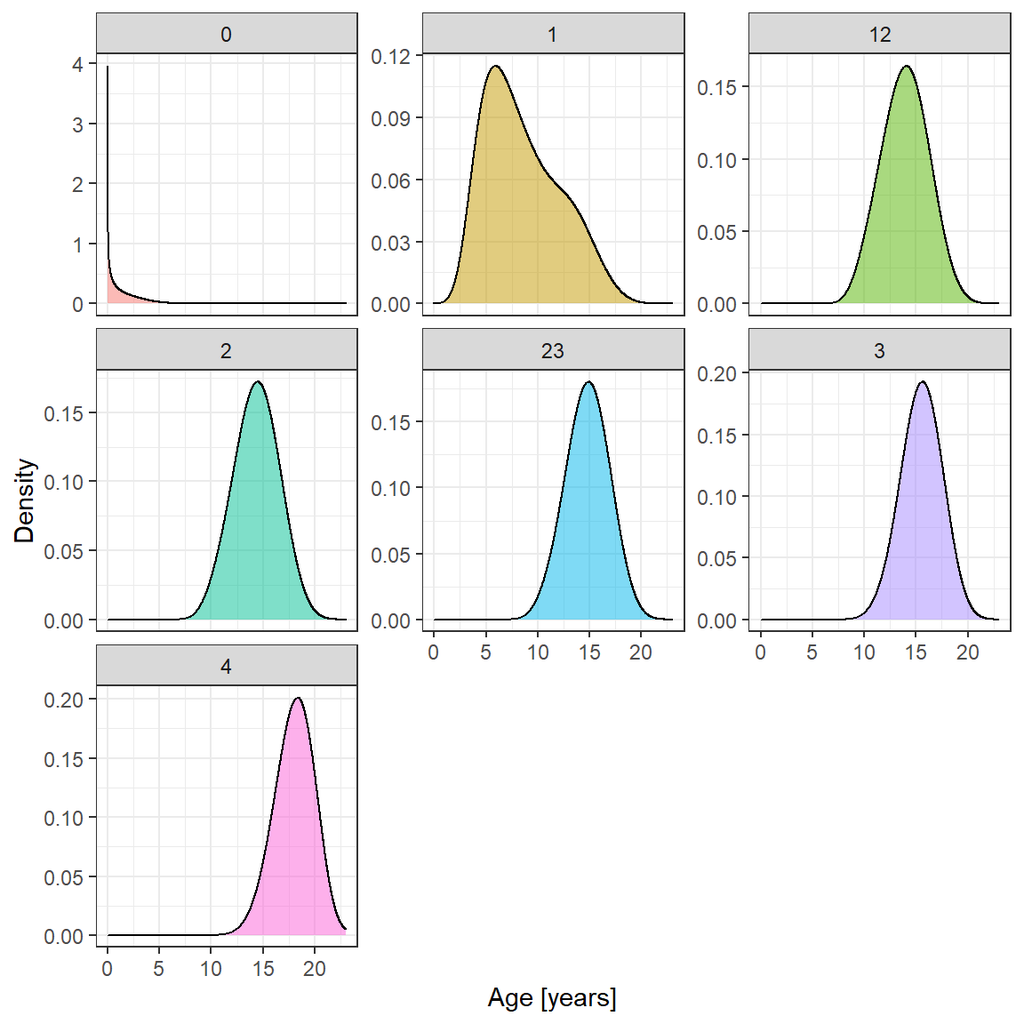

```r
ggplot(hme_post_df) +
  geom_area(aes(x=x, y=density, fill=factor(stage)),
            color="black", alpha=0.5) +   # fills space under line
  labs(x="Age [years]", y="Density", fill="Stage") +  # sets the labels
  theme_bw() +  # uses black and white theme
  theme(legend.position="none") +  # removes legend
  facet_wrap(~stage, scales="free_y")   # facets by stage, free y-axis
```

### Point and Credible Intervals for Predictions

Similar to plotting the point estimate and credible intervals for each ordinal stage, we can achieve similar plots for predictions regardless of model type and input variables. These are helpful for visualizing accuracy and precision of the model where:

- accuracy = whether the known value is within the credible interval
- precision = this distance between the point estimate and known value

```
To demonstrate, we will use the multivariate model predictions calculated during the `multivariate_batch_calc()` example.
```

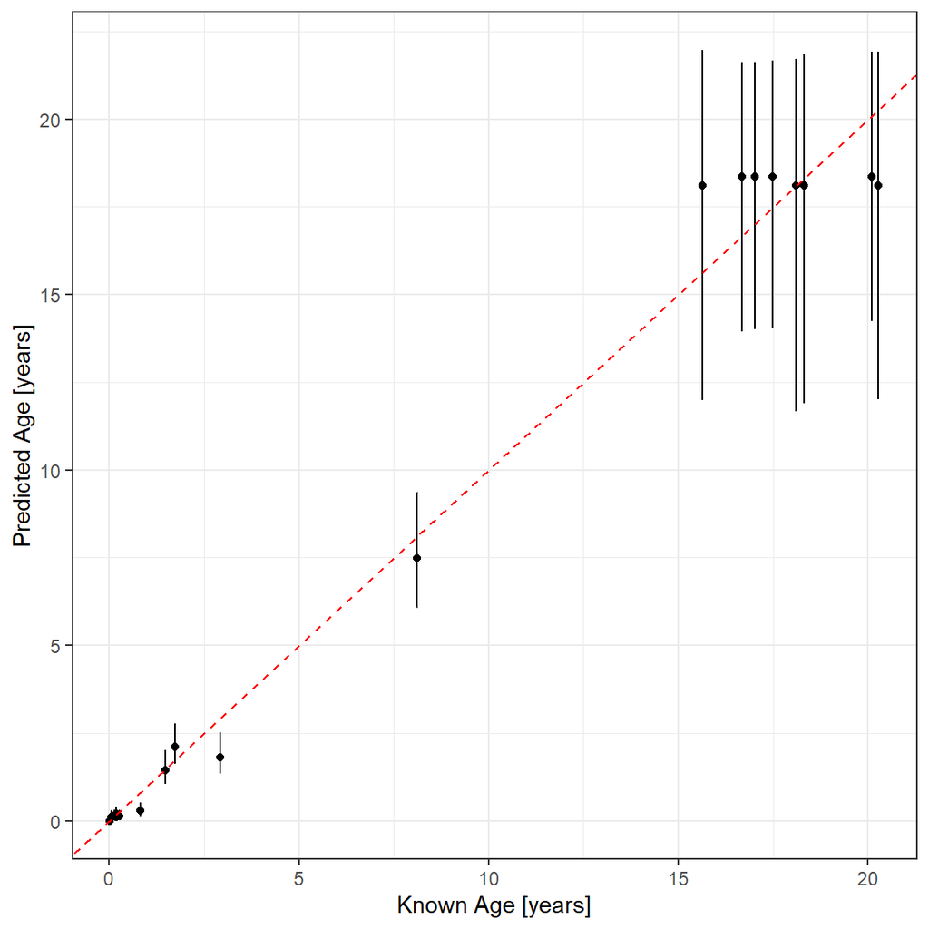

```r
multi_pred <- read.csv("results/cdep_model_US_test_predictions.csv")

ggplot(multi_pred) +
  geom_errorbar(aes(x=agey, ymin=lower95, ymax=upper95)) +
  geom_point(aes(x=agey, y=xmode)) +
  geom_abline(slope=1, intercept=0, color="red", linetype="dashed") +
  labs(x="Known Age [years]", y="Predicted Age [years]") +
  theme_bw()
```

This plot is a great way of observing model performance using test data, although larger sample sizes will start to become busy. We encourage the users to explore other ways of visualizing the outputs of models generated by the MCP algorithm.

# Contact Us!

If you have made it all to the way to the end of this document, the authors commend and thank you for your time, patience, and curiosity about the MCP algorithm. We hope you have found this vignette informative and helpful.

If you have any questions about this document or the MCP algorithm and the `yada` package, or would like to provide any suggestions, please contact us at:

- **Elaine Y. Chu** ([elainechu@nevada.unr.edu]), Author and maintainer
- **Kyra E. Stull** ([kstull@unr.edu]), Author
- **Louise K. Corron** ([lcorron@unr.edu]), Author
- **Michael H. Price** ([michaelholtonprice@gmail.com]), Author

### Funding Statement

This work was funded by the National Institute of Justice (Awards [2015-DN-BX-K409](https://nij.ojp.gov/funding/awards/2015-dn-bx-k409) and [2017-DN-BX-0144](https://nij.ojp.gov/funding/awards/2017-dn-bx-0144)) and the National Science Foundation ([BCS-1551913](https://www.nsf.gov/awardsearch/showAward?AWD_ID=1551913&HistoricalAwards=false)). Opinions expressed herein do not necessarily represent the official position or policies of the U.S. Department of Justice or the National Science Foundation.